# Word Prediction

April 25, 2018

## **Motivation** for Next Word Prediction

In **Natural Language Processing** it is valuable to be able to predict the next word. This starts with assigning probabilities to words, phrases or sentences.

- **Speech Recognition**: It helps to know more probable sentences to decode a garbled speech audio input
- **Spelling or Grammar Correction**: Detecting an unlikely phrase can identify potential mistakes in the text
- **Machine Translation**: Known sentence probabilities can be used to reconstruct translations into the target language.

[figure not shown]

## **Approach** : Prediction Model

The goal is to use **probabilistic language modeling** to compute the probability of upcoming words and fill in the most probable option.

To compute the probability of a sequence of words, we use the **Chain Rule of Probability** along with the simplifying **Markov Assumption**. Instead of calculating the probability of the next word given all of the preceding words, we approximate this using only a few preceding words.

**N-gram model** uses N-1 words to approximate the Nth word.

If the N-gram has zero counts, then the **backoff model** allows to approximate using the (N-1)-gram.

## **Approach** : Learning from Sample Texts

[figure not shown]

1. Gather training data set using sample texts from twitter, news and blogs. Generate a **corpus**.
2. Clean the corpus by removing numbers, bad words and punctuations
3. **Tokenize** the clean corpus into words
4. Convert the tokens into **n-grams**, pairs of n words that appear in sequence in the corpus
5. Create a **document feature matrix** to generate a table of n-grams and their corresponding frequency in the corpus

## How to Use the [App](https://bbamini.shinyapps.io/Shiny/)?

1. Write phrases in the text box and press "Predict".
2. Backoff model prediction will display in the main panel along with other predictions made using shorter N-grams.
3. The input text can be updated by selecting a predicted word.

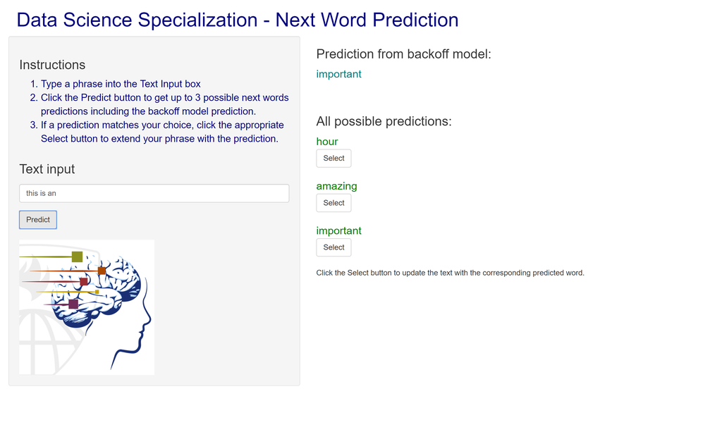